# Getting Started with R Graphics

Xiaojing Dong

October 2, 2017

R Graphics

This session helps you get started with R graphics. Web links are provided for more detailed instructions on how to fully leverage the functionality provided by these R packages. In this session, we briefly mention three different ways to plot your data. The first uses the basic **plot()** function. The second uses the package **ggplot**. Only the simpler version of **ggplot()** function is provided, which is the function **qplot()** for quick start. Finally, the **rbokeh** package was introduced.

Among all the three methods, **ggplot** package makes better-looking plots comparing to the basic **plot()** function, and therefore has been widely adopted. The **rbokeh** package is relatively new, hence the community support is less available comparing to the **ggplot()** package.

Before started, first load the data we used in the regression analysis.

```r
df = read.csv("Coffee_inClass.csv",header = TRUE)
```

## Plotting with Basic R package

R provides basic package for plotting data, using function **plot()**. This subsection offers basic descriptions on how to get started on using **plot()**.

### Basic Plotting

The command used for plotting in the R_regression session is copied here

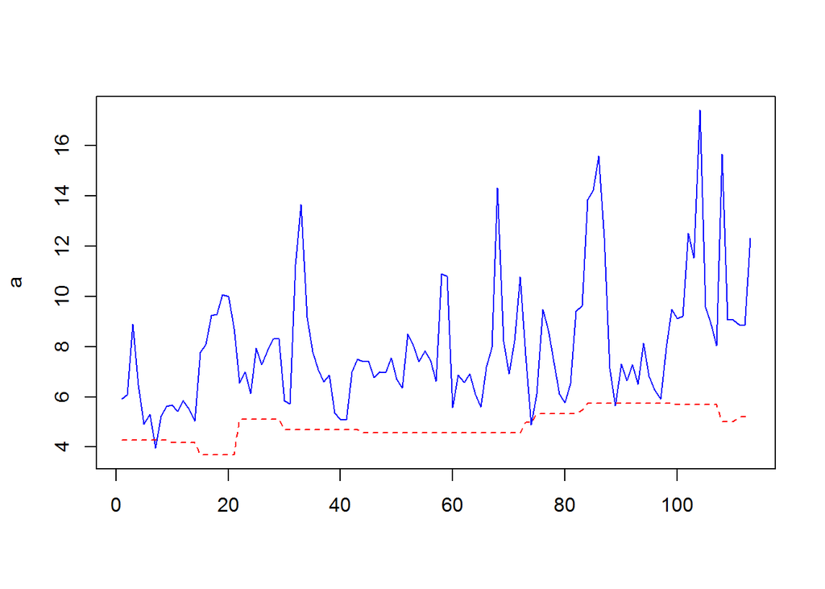

```r
a = cbind(df$Sales1/1000,df$Price1)
source("multiplot.R")
matplot(a,type="l",col=c("blue","red"))
```

To learn the details of the options included in the function **matplot()** or **plot()**, you can get help using

```r
help("par")
```

Here are some basics. In the above use of **matplot()**, a is the matrix containing the two variables we want to plot together. Below are explanations of the other options utilized in this command.

*type* indicates the type of plot for each variable. “p” for points, “l” for lines, “b” for both, “c” for the lines part alone of “b”, “o” for both ‘overplotted’, “h” for ‘histogram’ like (or ‘high-density’) vertical lines, “s” for stair steps, “S” for other steps, see ‘Details’ below, “n” for no plotting.

*col* indicates the color for each plot, similar to pch, the first value refers to the color for the first plot, the second value for the second plot, the third value for the third plot, etc.

To demonstrate the *type* definition in **plot()**, we load the data used in the Regression session again

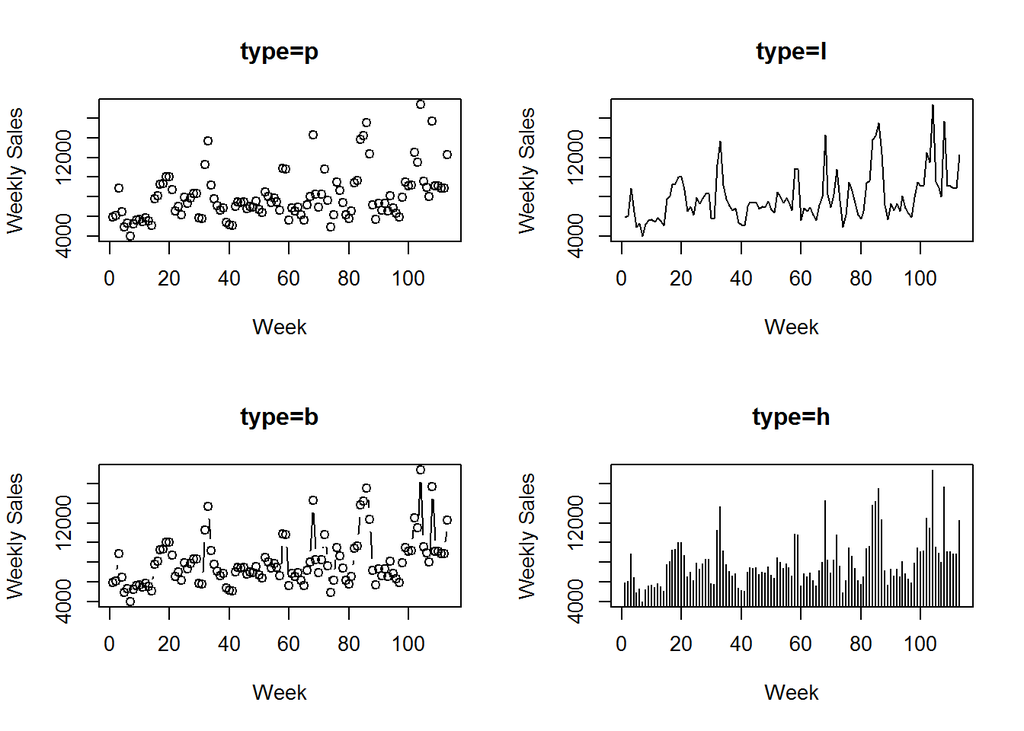

```r
Y=df$Sales1
def.type = par(mfrow=c(2,2))
plot(Y,type="p",main="type=p",xlab="Week",ylab="Weekly Sales")
plot(Y,type="l",main="type=l",xlab="Week",ylab="Weekly Sales")
plot(Y,type="b",main="type=b",xlab="Week",ylab="Weekly Sales")
plot(Y,type="h",main="type=h",xlab="Week",ylab="Weekly Sales")
```

```r
par(def.type) #reset the plot options back to defaul
```

In the above commands, **mfrow()** defines that 4 graphics are going to be plotted on the same page, with 2 rows and 2 columns. Without such a command, each plot will be shown on a separate page. The 4 plots demonstrating the definintion for type are displayed altogheter.

In addition to the parameters descirbed above, you can also specify the line width using *lwd*, the line type using *lty*, and define the range of X or Y using *xlim* or *ylim*. See the examples below, using type=“l”.

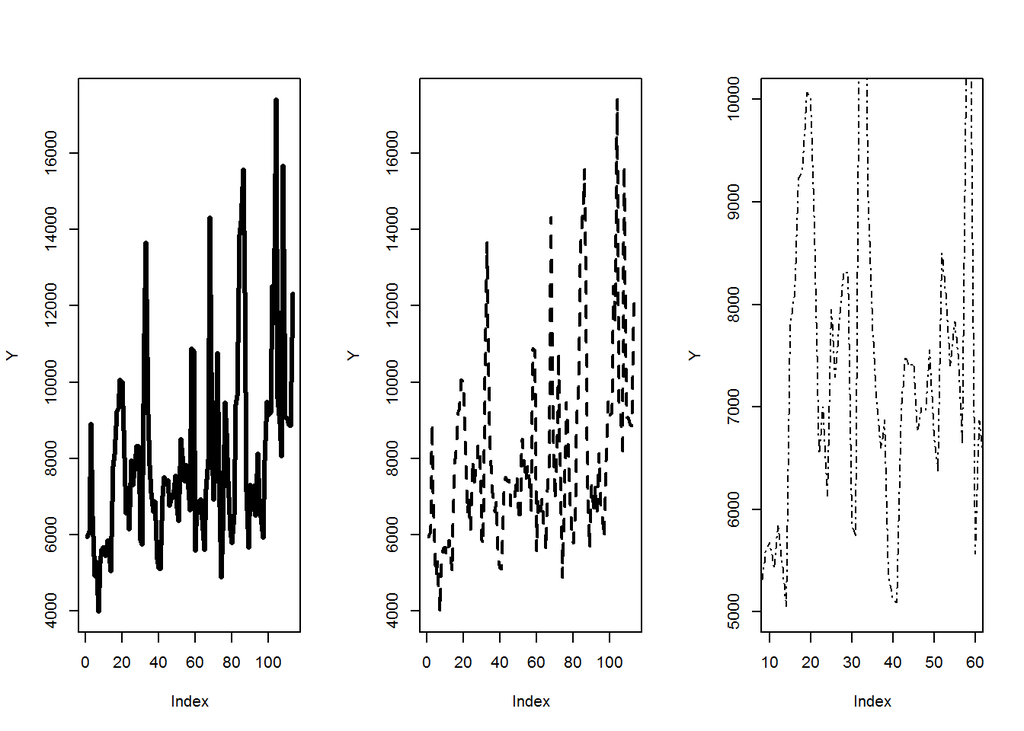

```r
def.par = par(mfrow=c(1,3))
plot(Y,type="l",lwd=3)
plot(Y,type="l",lty="dashed",lwd=2)
plot(Y,type="l",lty="dotdash",xlim=c(10,60),ylim=c(5000,10000))
```

```r
par(def.par)
```

Finally, use **par()** to reset the plot parameters back to default, if not, all the futuer call to the **plot()** function will have the parameters defined for the above plots.

### Adding Legend to the Plot

Right after the **plot()** function in the regression example, we also use a command to add legend on the plots providing the name of each variable being plotted, using the function **legend()**, copied below

legend(‘topleft’,c(“Sales”,“Price”),lty=1:2,col=c(“blue”,“red”),cex=.75)

In this command,

*c(“Sales”,“Price”)* shows the name of the variables

*lty* specifies the line type, which is necessary for line plots. It is specified either as an integer (0=blank, 1=solid (default), 2=dashed, 3=dotted, 4=dotdash, 5=longdash, 6=twodash) or as one of the character strings “blank”, “solid”, “dashed”, “dotted”, “dotdash”, “longdash”, or “twodash”, where “blank” uses ‘invisible lines’ (i.e., does not draw them).

*cex* the relative size of the texts in the legend, comparing to the regular text size.

## Plotting with *ggplot2* Package

The above subsection describes the **plot()** function in R and some of its parameter definitions, next we’ll introduce an R Package that has been widely used for easier plotting in R, called the *ggplot2* package . Here is a [nice description](http://www.statmethods.net/advgraphs/ggplot2.html) on how to use a simpler version of this package, using function **qplot()**. For more details of the detailed reference on the full power of **ggplot()**, please refer to the [online reference](http://ggplot2.tidyverse.org/reference/).

To utilize this, we need to first get the package and load the library

```r
install.packages("ggplot2")
```

In most cases, we just use the function **qplot()**

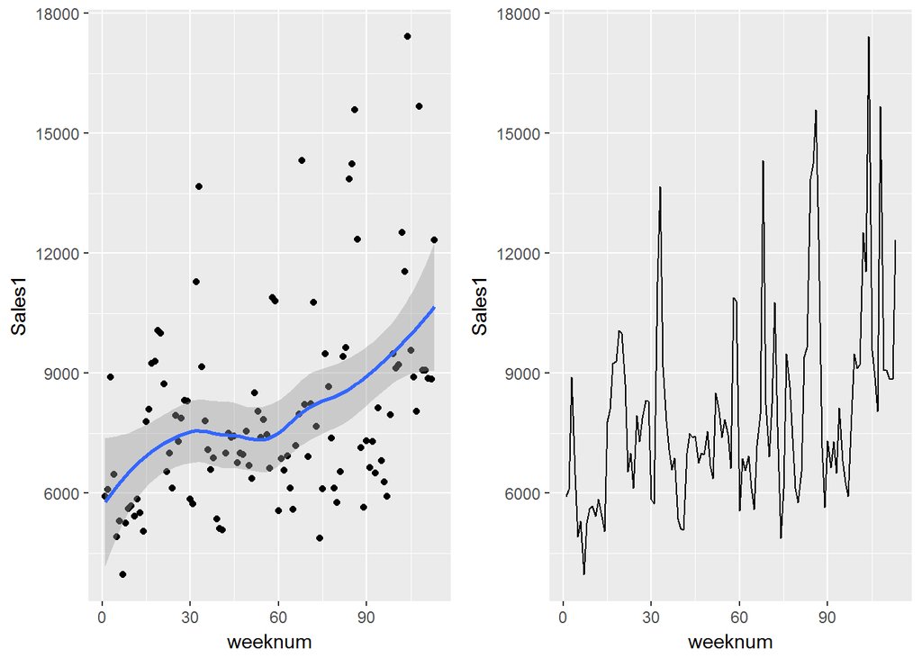

```r
library(ggplot2)
p1 = qplot(x=weeknum,y=Sales1, data=df, geom=c("point","smooth"))
p2 = qplot(x=weeknum,y=Sales1, data=df, geom=c("line"))
multiplot(p1,p2,cols=2)
```

In this command, **geom** specifies the type of plots to make. It can take values like “point”, “smooth”, “boxplot”, “line”, “histogram”, “density”, “bar” and “jitter”

## Plotting with *rbokeh* Package

A more sophisticated R graphics package is called “rbokeh”. To use it, first install the package and load the library.

```r
install.packages("rbokeh")
```

```r
library(rbokeh)
p = figure()
```

```r
salesk = df$Sales1/1000
price = df$Price1
```

Then we can add another layer for the price variable, before that, we change the scale of the sales variable to make the two variables seen on the same plot.

```r
p %>% ly_lines( x=c(1:39), y=salesk, legend="Sales") %>%
      ly_points(x=c(1:39),y=salesk, hover=salesk) %>%
      ly_lines(x=c(1:39),y=price, type=2, col="red", legend="Price") %>%
      ly_points(x=c(1:39),y=price, hover=price)
```

[interactive chart not shown]

The **hover** option allows the data value to be shown when the mouse is moved there. This functionality would be hard to implement in the other two plotting functions/packages we mentioned before.